# Hands-on Exercise 1: A Layered Grammar of Graphics

### Working with theme

The code chunk below plot a horizontal bar chart using theme_gray().

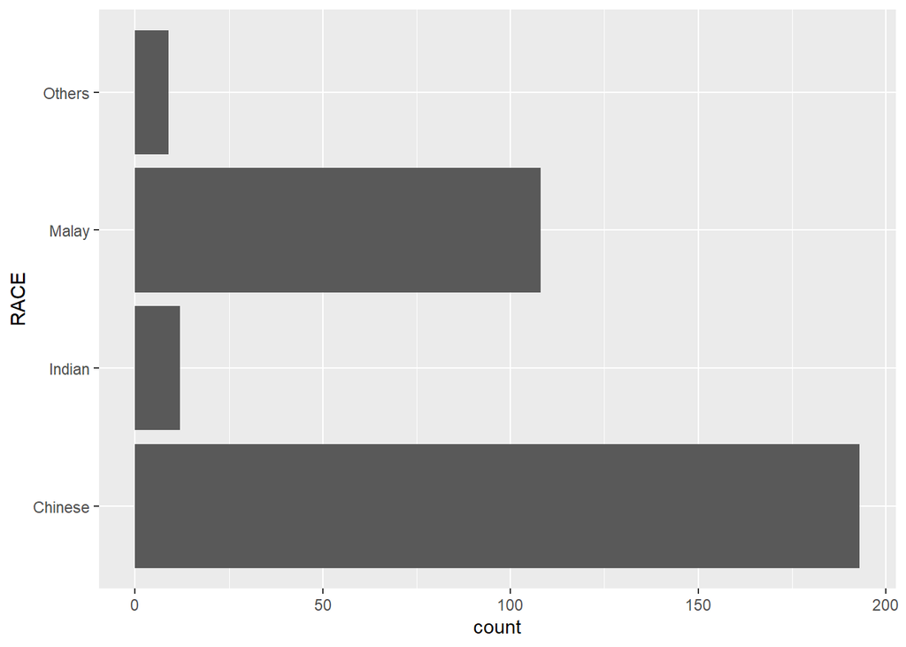

```r
ggplot(data=exam_data, aes(x=RACE)) +
  geom_bar() +
  coord_flip() +
  theme_gray()
```

**theme_classic()**

A horizontal bar chart plotted using theme_classic().

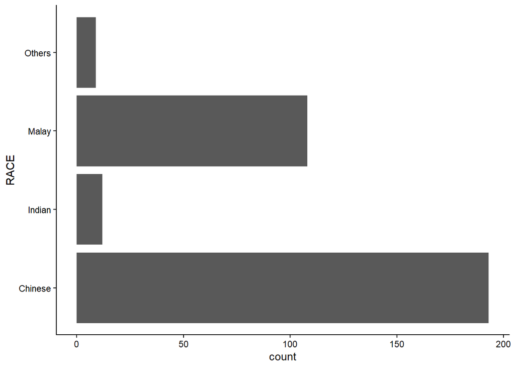

```r
ggplot(data=exam_data, aes(x=RACE)) +
  geom_bar() +
  coord_flip() +
  theme_classic()
```

**theme_minimal()**

A horizontal bar chart plotted using theme_minimal().

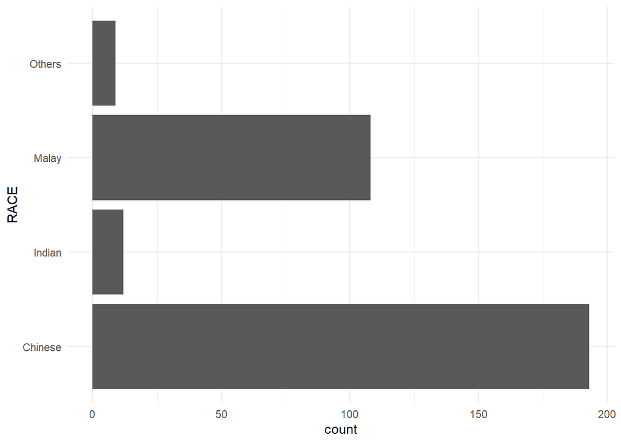

```r
ggplot(data=exam_data, aes(x=RACE)) +
  geom_bar() +
  coord_flip() +
  theme_minimal()
```

**theme_light()**

A horizontal bar chart plotted using theme_light().

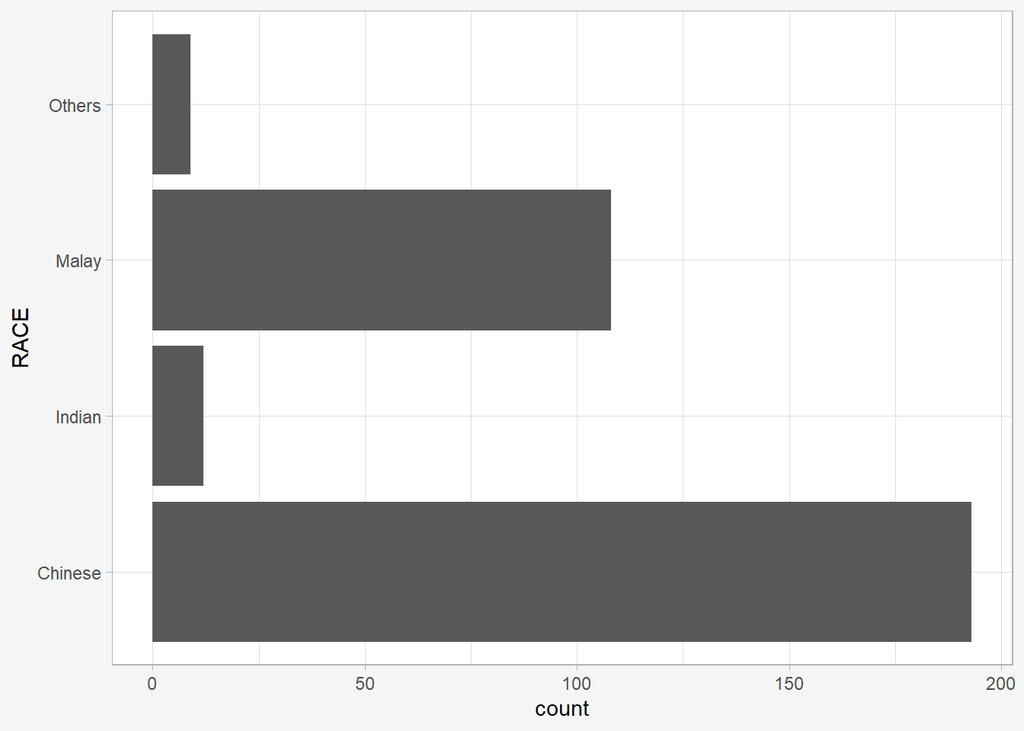

```r
ggplot(data=exam_data, aes(x=RACE)) +
  geom_bar() +
  coord_flip() +
  theme_light() +
      theme(plot.background=element_rect(fill="#f5f5f5",colour="#f5f5f5"))
```

**theme_bw()**

A horizontal bar chart plotted using theme_bw().

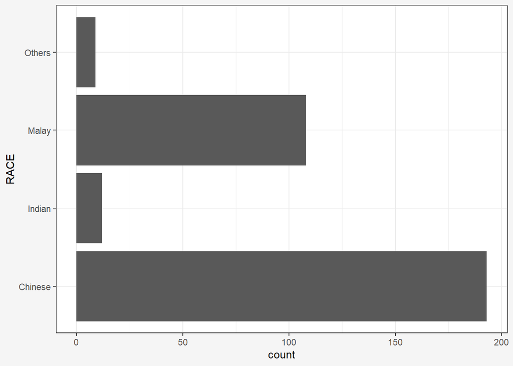

```r
ggplot(data=exam_data, aes(x=RACE)) +
  geom_bar() +
  coord_flip() +
  theme_bw() +
      theme(plot.background=element_rect(fill="#f5f5f5",colour="#f5f5f5"))
```

## 11. Reference

- Kam, T.S. (2023). [A Layered Grammar of Graphics: ggplot2 methods](https://r4va.netlify.app/chap01).
- Hadley Wickham (2023) ggplot2: [Elegant Graphics for Data Analysis. Online 3rd edition](https://ggplot2-book.org/).
- Winston Chang (2013) [R Graphics Cookbook 2nd edition. Online version](https://r-graphics.org/).
- Healy, Kieran (2019) Data Visualization: [A practical introduction. Online version](https://socviz.co/).
- [Learning ggplot2 on Paper – Components](https://henrywang.nl/learning-ggplot2-on-paper-components/)
- [Learning ggplot2 on Paper – Layer](https://henrywang.nl/learning-ggplot2-on-paper-layer/)
- [Learning ggplot2 on Paper – Scale](https://henrywang.nl/tag/learning-ggplot2-on-paper/)